# Practice Assignment

# Part 1: Create a README

See homepage for details.

# Part 2: Data inspection with R

The dataset `Titanic` would be used for this part.

## Part 2.1: Passenger breakdown

```r
dat <- data.frame(Titanic)
```

**How many children and adults were on Titanic?**

```r
child <-filter(dat, dat$Age == "Child")
child.num <- sum(child$Freq)
adult <-filter(dat, dat$Age == "Adult")
adult.num <- sum(adult$Freq)
child.num; adult.num
```

```
## [1] 109
```

```
## [1] 2092
```

- There are 109 children and 2092 adults on the Titantic.

**Were there more female adult or male adult passengers?**

```r
# count the number of adults and kids for each sex
fe.ad <- filter(dat, dat$Sex == "Female" & dat$Age  == "Adult")
fe.num <- sum(fe.ad$Freq)
m.ad <- filter(dat, dat$Sex == "Male" & dat$Age  == "Adult")
m.num <- sum(m.ad$Freq)
fe.num; m.num
```

```
## [1] 425
```

```
## [1] 1667
```

- There are 425 female adults and 1667 male adults on the ship. So, there are more male adults.

## Part 2.2: Survival

**Did the children have better survival rate than the adults?**

```r
c.sur <- filter(dat, dat$Age == "Child" & dat$Survived == "Yes")
a.sur <- filter(dat, dat$Age == "Adult" & dat$Survived == "Yes")
c.rate <- sum(c.sur$Freq)/child.num
a.rate <- sum(a.sur$Freq)/adult.num
c.rate; a.rate
```

```
## [1] 0.5229358
```

```
## [1] 0.3126195
```

- The survival rate for children is around 52.3% whereas that for adults is around 31.3%. Hence, yes, children had a better survival rate than adults.

**Which class of passengers have a better survival rate? (Crew, first class, second class, third class)**

```r
c1 <- filter(dat, dat$Class == "1st")
c2 <- filter(dat, dat$Class == "2nd")
c3 <- filter(dat, dat$Class == "3rd")
cc <- filter(dat, dat$Class == "Crew")
c1.s <- filter(c1, c1$Survived == "Yes")
c2.s <- filter(c2, c2$Survived == "Yes")
c3.s <- filter(c3, c3$Survived == "Yes")
cc.s <- filter(cc, cc$Survived == "Yes")
c1.r <- sum(c1.s$Freq)/sum(c1$Freq)
c2.r <- sum(c2.s$Freq)/sum(c2$Freq)
c3.r <- sum(c3.s$Freq)/sum(c3$Freq)
cc.r <- sum(cc.s$Freq)/sum(cc$Freq)
c1.r; c2.r; c3.r; cc.r
```

```
## [1] 0.6246154
```

```
## [1] 0.4140351
```

```
## [1] 0.2521246
```

```
## [1] 0.239548
```

# Part 3: Data Visualization

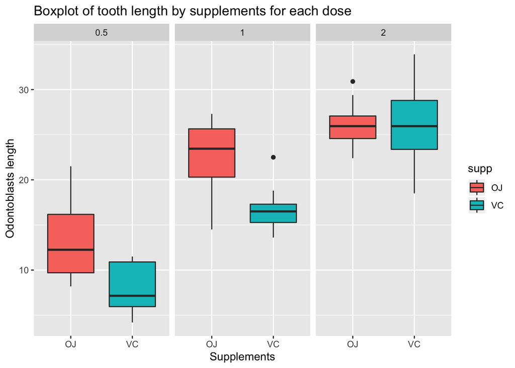

```r
dat2 <- ToothGrowth

ggplot(aes(x = supp, y = len), data = dat2) +
  geom_boxplot(aes(fill = supp)) + facet_wrap(~ dose) +
  ggtitle("Boxplot of tooth length by supplements for each dose") +
  xlab("Supplements") + ylab("Odontoblasts length")
```

The figure above shows the relationship among the types of supplements used, dosage of each type of supplements, and the odontoblasts’ length in 60 guinea pigs. I am interested in exploring how would different combinations of supplements and their dosages alter the odontoblasts’ length as well as depicting descriptive statistics like variance, median, max, and min related to length. Hence, boxplot is the most effective and easiest visualization tool to accomplish this goal.